# Homework 7

Yunting Chiu

2021-04-09

1. (**7.1**) State the number of degrees of freedom that are associated with each of the following extra sums of squares: SSReg(X1 | X2), SSReg(X2 | X1, X3), SSReg(X1, X2 | X3, X4), SSReg(X1, X2, X3 | X4, X5).

A note about the notation. SSReg(A | B) is the extra sum of squares that appeared as aresult of including variables A into the regression model that already had variables B in it. Thus, it is used to compare the full model with both A and B in it against the reduced model with only B.

Ans: We can calculate degrees of freedom by counting the number of variables to the left of the “|”. - SSReg(X1 | X2) = 1 - SSReg(X2 | X1, X3) = 1 - SSReg(X1, X2 | X3, X4) = 2 - SSReg(X1, X2, X3 | X4, X5) = 3

2. (**7.2**) Explain in what sense the regression sum of squares SSReg(X1) is an extra sum of squares.
- Extra sum of squares uses extra sums of squares in tests for regression coefficients. For example, there is a response variable Y and 2 predictor variables X1 and X2:
- The reduce model is Y = $\beta0$ + $\beta1$X1 + ei and compute SSE(X1)
- The full model is Y = $\beta0$ + $\beta1$X1 + $\beta2$X2 + ei and compute SSE(X1, X2)
- So the equation can be denoted as SSE(X1) = SSE(X1, X2) + SS? How can we define SS? As the extra sum of squares and denote it by SSR(X2|X1) so we can write as
  $$SSR(X2|X1) = SSE(X1) - SSE(X1,X2)$$
- SSR(X2|X1) calculates the decrease in SSE when X2 is added to the regression model, given X1 is already present.

Reference:

- https://365datascience.com/tutorials/statistics-tutorials/sum-squares/
- https://www.stat.colostate.edu/~riczw/teach/STAT540_F15/Lecture/lec09.pdf
3. (**7.28b**) For a multiple regression model with five X variables, what is the relevant extra sum of squares for testing

The equation might be:
$$Y = \beta0 + \beta1X1 + \beta2X2 + \beta3X3 + \beta4X4 + \beta5X5 + ei$$
(a) whether or not $\beta5$ = 0?
- SSR(X5 | X2, X3, X4, X5)
(b) whether or not $\beta2$ = $\beta4$ = 0?
- SSR(X2, X4 | X1, X3, X5)

4. (**7.28b, Stat-615 only**) Show that SSReg(X1, X2, X3, X4) = SSReg(X2, X3)+SSReg(X1|X2, X3)+SSReg(X4 | X1, X2, X3)

Reference:

- https://www.stat.colostate.edu/~riczw/teach/STAT540_F15/Lecture/lec09.pdf
- https://www.math.arizona.edu/~piegorsch/571A/STAT571A.Ch07.pdf

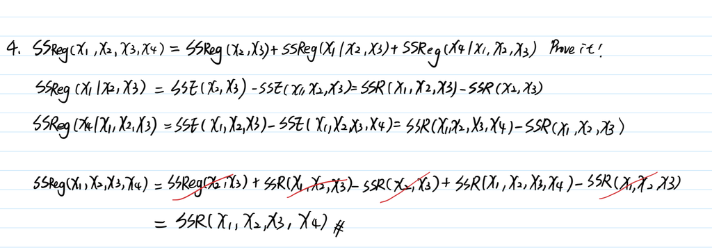

5. (**7.3, 7.24, 7.30**) Continue working with the Brand Preference data, which are available on our Blackboard, on http://statweb.lsu.edu/EXSTWeb/StatLab/DataSets/NKNWData/CH06PR05.txt, and in the previous homework.

Recall the variables: It was collected to study the relation between degree of brand liking (Y) and moisture content (X1) and sweetness (X2) of the product.

1. Obtain the ANOVA table that decomposes the regression sum of squares into extra sum of squares associated *with X1* and *with X2, given X1*.
- SSR(X1) = 1566.45
- SSR(X2|X1) = 306.25

```r
brand <- read.table("./data/CH06PR05.txt")
brand %>%
  rename(Y = V1, X1 = V2, X2 = V3) -> brand

# SSR(X1)
X1 <- lm(Y ~ X1, data = brand)

# SSR(X2|X1)
X2givenX1 <- lm(Y ~ X1 + X2, data = brand)

anova(X1)
```

|  | Df | Sum Sq | Mean Sq | F value | Pr(>F) |
| --- | --- | --- | --- | --- | --- |
| X1 | 1 | 1566.45 | 1566.45000 | 54.75047 | 3.356014e-06 |
| Residuals | 14 | 400.55 | 28.61071 | NA | NA |

```r
anova(X2givenX1)
```

|  | Df | Sum Sq | Mean Sq | F value | Pr(>F) |
| --- | --- | --- | --- | --- | --- |
| X1 | 1 | 1566.45 | 1566.450000 | 215.94751 | 1.778029e-09 |
| X2 | 1 | 306.25 | 306.250000 | 42.21898 | 2.011047e-05 |
| Residuals | 13 | 94.30 | 7.253846 | NA | NA |

2. Test whether X2 can be dropped from the model while X1 is retained.

Consider dropping X2, the hypothesis is H0: $\beta2$ = 0 vs $\beta2 \neq 0$. According to the analysis of variance table above, the p-value of X2 is 2.011e-05, indicating that there is evidence that $\beta2 \neq 0$, so X2 cannot be removed from the model.

3. Fit first-order simple linear regression for relating brand liking (Y) to moisture content (X1).

```r
summary(X1)$coefficients[, 1]
```

```
## (Intercept)          X1
##      50.775       4.425
```

$$\hat{Y} = 50.775 + 4.425X_1$$

4. Compare the estimated regression coefficient for X1 with the corresponding coefficient obtained in (a).
- In the `X2givenX1` model, the estimated regression coefficient for X1 is 4.425.
- In the `X1` model, the estimated regression coefficient for X1 is 4.425, too.

```r
summary(X2givenX1)$coefficients[2,1]
```

```
## [1] 4.425
```

```r
summary(X1)$coefficients[2,1]
```

```
## [1] 4.425
```

5. Does SSreg(X1) equal SSreg(X1|X2) here? Is the difference substantial?
- There are no different between sum of squares of X1. The first model SSReg(X1) is 1566.45, and the second model SSReg(X1|X2) is 1566.45.

```r
# SSReg(X1)
anova(X1)
```

|  | Df | Sum Sq | Mean Sq | F value | Pr(>F) |
| --- | --- | --- | --- | --- | --- |
| X1 | 1 | 1566.45 | 1566.45000 | 54.75047 | 3.356014e-06 |
| Residuals | 14 | 400.55 | 28.61071 | NA | NA |

```r
# SSReg(X1|X2)
X1givenX2 <- lm(Y ~ X2 + X1, data = brand)
anova(X1givenX2)
```

|  | Df | Sum Sq | Mean Sq | F value | Pr(>F) |
| --- | --- | --- | --- | --- | --- |
| X2 | 1 | 306.25 | 306.250000 | 42.21898 | 2.011047e-05 |
| X1 | 1 | 1566.45 | 1566.450000 | 215.94751 | 1.778029e-09 |
| Residuals | 13 | 94.30 | 7.253846 | NA | NA |

- Regress Y on X2 and obtain the residuals.

```r
lm.fit.5fa <- lm(Y ~ X2 , data = brand)
lm.fit.5fa$residuals -> a
a
```

```
##       1       2       3       4       5       6       7       8       9      10
## -13.375 -13.125 -16.375 -10.125  -5.375  -6.125  -6.375  -3.125   5.625   2.875
##      11      12      13      14      15      16
##   8.625   6.875  10.625   8.875  16.625  13.875
```

- Regress X1 on X2 and obtain the residuals.

```r
lm.fit.5fb <- (lm(X1 ~ X2, data = brand))
lm.fit.5fb$residuals -> b
b
```

```
##  1  2  3  4  5  6  7  8  9 10 11 12 13 14 15 16
## -3 -3 -3 -3 -1 -1 -1 -1  1  1  1  1  3  3  3  3
```

- Regress residuals from the model “Y on X2” on residuals from the model “X1 on X2”; compare the estimated slope, error sum of squares with #1. What about $R^2$?
- The regression of `Y` on `X2`: estimated slope is 4.375, SSE is 1660.75, $R^2$ is 0.1557.
- The regression of `Y` and `X1` on `X2`: estimated slope is 4.425, SSE is 94.3, $R^2$ is 0.9432.
- Because these two model are not regressing the same size so these two R-squares are completely different.

```r
lm.fit.5fc <- lm(a ~ b)
summary(lm.fit.5fa) # lm(Y ~ X2)
```

```
##
## Call:
## lm(formula = Y ~ X2, data = brand)
##
## Residuals:
##     Min      1Q  Median      3Q     Max
## -16.375  -7.312  -0.125   8.688  16.625
##
## Coefficients:
##             Estimate Std. Error t value Pr(>|t|)
## (Intercept)   68.625      8.610   7.970 1.43e-06 ***
## X2             4.375      2.723   1.607     0.13
## ---
## Signif. codes:  0 '***' 0.001 '**' 0.01 '*' 0.05 '.' 0.1 ' ' 1
##
## Residual standard error: 10.89 on 14 degrees of freedom
## Multiple R-squared:  0.1557, Adjusted R-squared:  0.09539
## F-statistic: 2.582 on 1 and 14 DF,  p-value: 0.1304
```

```r
anova(lm.fit.5fa)
```

|  | Df | Sum Sq | Mean Sq | F value | Pr(>F) |
| --- | --- | --- | --- | --- | --- |
| X2 | 1 | 306.25 | 306.250 | 2.581665 | 0.1304203 |
| Residuals | 14 | 1660.75 | 118.625 | NA | NA |

```r
summary(lm.fit.5fc)
```

```
##
## Call:
## lm(formula = a ~ b)
##
## Residuals:
##    Min     1Q Median     3Q    Max
## -4.400 -1.762  0.025  1.587  4.200
##
## Coefficients:
##               Estimate Std. Error t value Pr(>|t|)
## (Intercept) -4.718e-17  6.488e-01    0.00        1
## b            4.425e+00  2.902e-01   15.25 4.09e-10 ***
## ---
## Signif. codes:  0 '***' 0.001 '**' 0.01 '*' 0.05 '.' 0.1 ' ' 1
##
## Residual standard error: 2.595 on 14 degrees of freedom
## Multiple R-squared:  0.9432, Adjusted R-squared:  0.9392
## F-statistic: 232.6 on 1 and 14 DF,  p-value: 4.089e-10
```

```r
anova(lm.fit.5fc)
```

|  | Df | Sum Sq | Mean Sq | F value | Pr(>F) |
| --- | --- | --- | --- | --- | --- |
| b | 1 | 1566.45 | 1566.450000 | 232.5589 | 4.089332e-10 |
| Residuals | 14 | 94.30 | 6.735714 | NA | NA |

6. (**8.13**) Consider a regression model $Y = \beta_0 + \beta_1X_1 + \beta_2X_2 + e$, where X1 is a numerical variable, and X2 is a dummy variable. Sketch the response curves (the graphs of E(Y) as a function of X1 for different values of X2), if $\beta0$ = 25, $\beta1$ = 0.2, and $\beta2$ = -12.
- The blue line indicates the association between E(Y) and X1 when X2 = 0
- The green line indicates the association between E(Y) and X1 when X2 = 1

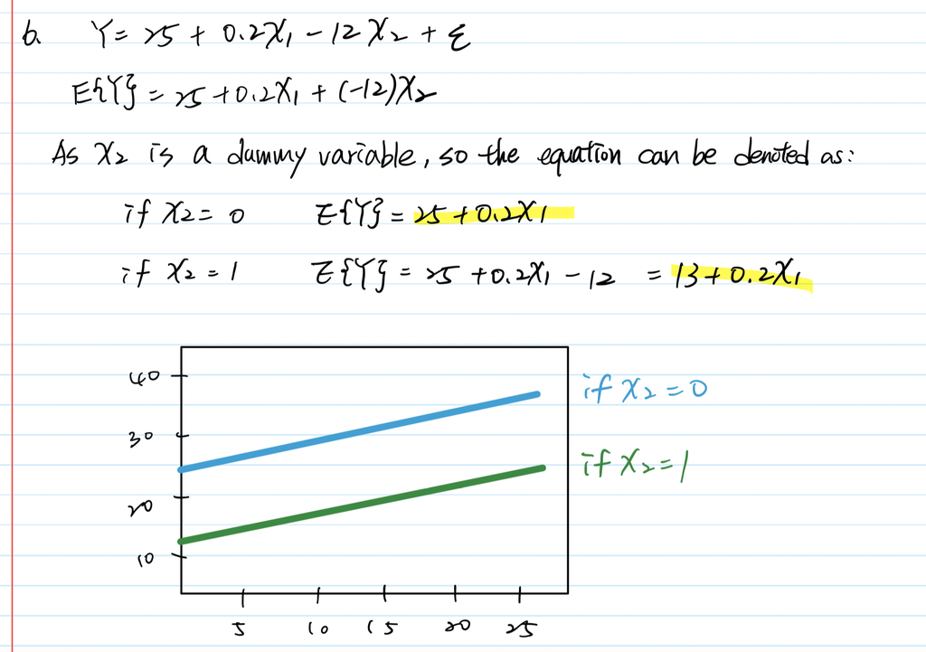

7. Continue the previous exercise. Sketch the response curves for the model with interaction, $Y = \beta_0 + \beta_1X_1 + \beta_2X_2 + \beta_3X_1X_2 + e$, given that $\beta_3$ = -0.2
- The red line indicates the association between E(Y) and X1 when X2 = 0
- The green line indicates the association between E(Y) and X1 when X2 = 1

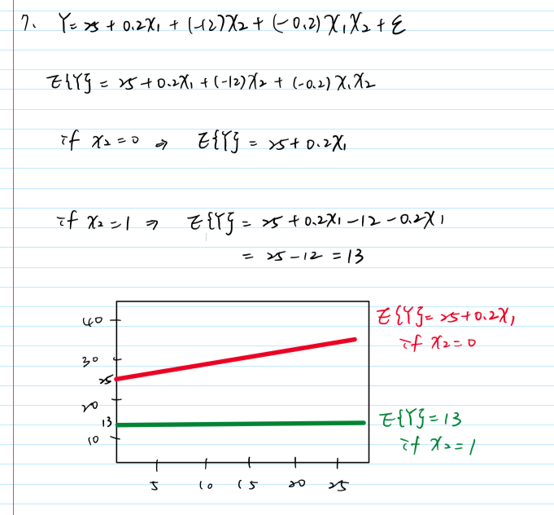

8. (**8.34**) In a regression study, three types of banks were involved, namely, (1) commercial, (2) mutual savings, and (3) savings and loan. Consider the following dummy variables for the type of bank:

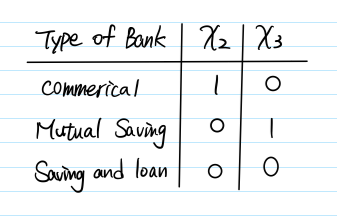

1. Develop the first-order linear regression model (no interactions) for relating last year’s profit or loss (Y) to size of bank (X1) and type of bank (X2, X3).
   $$Yi = \beta_0 + \beta_1X_1 + \beta_2X_2 + \beta_3X_3 + ei$$
2. State the response function for the three types of banks.
- In this data, we can see the `X2` and `X3` are dummy variables. Also, `Y` represents profit or loss, `X1` represents the size of bank.

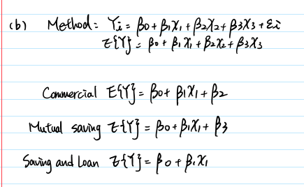

3. Interpret each of the following quantities: (1) $\beta_2$, (2) $\beta_3$, (3) $\beta_2-beta_3$.
1. $\beta_2$: The difference between the commercial bank’s and the savings and loan bank’s expected profit or loss.
2. $\beta_3$: The difference between the mutual saving bank’s and the savings and loan bank’s expected profit or loss.
3. $\beta_2-\beta_3$: The difference between the mutual saving bank’s and the commercial bank’s expected profit or loss.
4. (**8.16, 8.20**) Refer to our old GPA data

An assistant to the director of admissions conjectured that the predictive power of the model could be improved by adding information on whether the student had chosen a major field of concentration at the time the application was submitted. Suppose that the first 10 students chose their major when they applied.

```r
GPA <- read.table("./data/CH01PR19.txt")

GPA %>%
  rename(Y = "V1", X1 = "V2") -> GPA
# Suppose that the first 10 students chose their major when they applied.
GPA %>%
  mutate(X2 = 0) -> GPA
GPA$X2[1:10] = 1
head(GPA)
```

|  | Y | X1 | X2 |
| --- | --- | --- | --- |
| 1 | 3.897 | 21 | 1 |
| 2 | 3.885 | 14 | 1 |
| 3 | 3.778 | 28 | 1 |
| 4 | 2.540 | 22 | 1 |
| 5 | 3.028 | 21 | 1 |
| 6 | 3.865 | 31 | 1 |

1. Fit the regression model $Y = \beta_0 + \beta_1X_1 + \beta_2X_2 + e$, where X1 is the entrance test score and X2 = 1 if a student has indicated a major at the time of application, otherwise X2 = 0. State the estimated regression function.

```r
lm.fit <- lm(Y ~ X1 + X2, data = GPA)
summary(lm.fit)
```

```
##
## Call:
## lm(formula = Y ~ X1 + X2, data = GPA)
##
## Residuals:
##      Min       1Q   Median       3Q      Max
## -2.81035 -0.33271  0.02987  0.44702  1.15523
##
## Coefficients:
##             Estimate Std. Error t value Pr(>|t|)
## (Intercept)  2.11062    0.32220   6.551  1.6e-09 ***
## X1           0.03871    0.01282   3.018  0.00312 **
## X2           0.07728    0.20663   0.374  0.70910
## ---
## Signif. codes:  0 '***' 0.001 '**' 0.01 '*' 0.05 '.' 0.1 ' ' 1
##
## Residual standard error: 0.6254 on 117 degrees of freedom
## Multiple R-squared:  0.07373,    Adjusted R-squared:  0.05789
## F-statistic: 4.656 on 2 and 117 DF,  p-value: 0.01133
```

2. Test whether X2 can be dropped from the model, using $\alpha$ = 0.05.

Significance of the whole model is tested by H0 : $\beta_2 = 0$ vs H1 : $\beta_2 \neq 0$. With a large p-value 0.7091 and a small test statistic F = 0.1399, we fail to reject the null hypothesis, meaning that we have no evidence to conclude that `X2` is significant so `X2` may be remove from the model.

```r
lm.fit.dropedX2 <- lm(Y ~ X1, data = GPA)
anova(lm.fit, lm.fit.dropedX2)
```

|  | Res.Df | RSS | Df | Sum of Sq | F | Pr(>F) |
| --- | --- | --- | --- | --- | --- | --- |
| 1 | 117 | 45.76290 | NA | NA | NA | NA |
| 2 | 118 | 45.81761 | -1 | -0.05470289 | 0.1398565 | 0.7091006 |

3. Fit the regression model $Y = \beta_0 + \beta_1X_1 + \beta_2X_2 + \beta_3X_1X_2 + e$ and state the estimated regression function. Interpret $\beta_3$. Test significance of the interaction term.

```r
# interaction term
lm.fit.interaction <- lm(Y ~ X1 * X2, data = GPA)
summary(lm.fit.interaction)
```

```
##
## Call:
## lm(formula = Y ~ X1 * X2, data = GPA)
##
## Residuals:
##      Min       1Q   Median       3Q      Max
## -2.47832 -0.31337  0.04355  0.45001  1.07374
##
## Coefficients:
##             Estimate Std. Error t value Pr(>|t|)
## (Intercept)  1.83364    0.33492   5.475 2.57e-07 ***
## X1           0.04992    0.01336   3.738  0.00029 ***
## X2           2.49114    1.00135   2.488  0.01428 *
## X1:X2       -0.09635    0.03915  -2.461  0.01531 *
## ---
## Signif. codes:  0 '***' 0.001 '**' 0.01 '*' 0.05 '.' 0.1 ' ' 1
##
## Residual standard error: 0.6123 on 116 degrees of freedom
## Multiple R-squared:  0.1197, Adjusted R-squared:  0.09694
## F-statistic: 5.258 on 3 and 116 DF,  p-value: 0.001947
```

### State the Estimated Regression Function

$$\hat{Y} = 1.83364 + 0.04992X_1 + 2.49114X_2 - 0.09635X_1X_2$$

- If X2 = 0: $\hat{Y} = 1.83364 + 0.04992X_1$
- If X2 = 1: $\hat{Y} = 1.83364 + 0.04992X_1 + 2.49114 - 0.09635X_1 = 4.32478 - 0.04645X_1$
- As previous stated, `X2` = 1 is the student has indicated a major at the time of application, otherwise `X2` is 0. The estimated value of $\beta3$ is -0.09635, indicating that there is a expected difference value on GPA between the students in these two groups (whether they have indicated a major or not).